# Scripting in Abaqus with abapys

### Example: Plotting by Label

To plot the vertical stresses `S33` of an element (with label 1108) of instance *instBoden*, the following `PlotOutput()` call can be used. Additionally, a label to the $x$-axis and the $y$-axis, a title and a legend entry are added. The result is shown in figure 9.3.

Code 9.4: Plot vertical stress at one element over time.

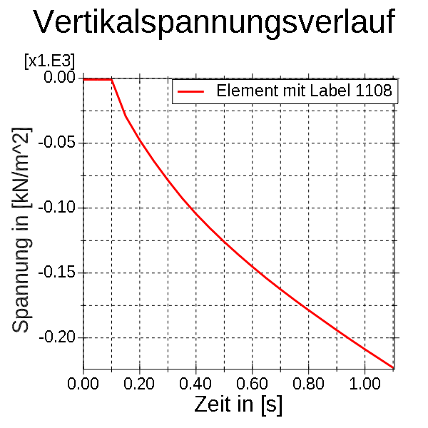

Figure 9.3: Stress over time on element labelled 1108.

```python
PlotOutput(session=session, odbname=odbname, yvar=('S', 'S33'), yvarposition=('instBoden', [1108]),
   ylabel='Spannung in [kN/m^2]', xlabel='Zeit in [s]', titel='Vertikalspannungsverlauf',
   legendeneintraege=['Element mit Label 1108']);
```

## 9.3 Process Output Data

This section focuses on two different kinds of output data: FieldOutput/HistoryOutput data and XY data. FieldOutput/HistoryOutput data is created and saved in the output database if requested in the model definition. XY data can be generated by one or more FieldOutput/HistoryOutput data sets present in the output data base (and may contain less points in time and/or space).

Often FieldOutput/HistoryOutput data and/or XY data should be gathered and exported to continue processing it in another program (like Octave or Matlab). There are two different functions implemented to save FieldOutputs: `FieldOutputSpeichern()` directly takes a FieldOutput chunk for all defined output nodes/elements in a specified step and frame (see code 9.5).

Code 9.5: Save FieldOutput for all elements at one step/frame.

```python
FieldOutputSpeichern(dateiname='spannung_eindruecken_10', session=session, odbname=odbname,
   fieldOutput='SVAVG', step=1, frame=10);
```

Alternatively a subset of the FieldOutput can be saved by generating XY data first. Using `FieldOutputVorbereiten()`, data from a FieldOutput can be collected for all steps and frames for certain points of interest (this is usually the right choice when the behaviour during the whole simulation is of interest). `XYDatenSpeichern()` can be used to save existing XY data. It requires the name of the XY data (e. g. output of `FieldOutputVorbereiten()`) passed to `xydatenname` as shown in code 9.6.

Code 9.6: Save FieldOutput at certain elements/sets for all steps/frames.

```python
spannung_element = FieldOutputVorbereiten(session=session, odbname=odbname,
   var=['SVAVG', 'SVAVG33'], varposition=('INSTBODEN', [9951]));
XYDatenSpeichern(dateiname='spannung_9951', session=session, xydatenname=spannung_element[0].name);
```

There is an additional function `XYDatenAnElementen()` to extract XY data from certain elements. As a preparation, elements are selected by a coordinate range, sorted by $z$-direction and their labels saved in *elem_sortiert* as described in code 5.10.

Now the relevant XY data can be extracted for one point in time with `XYDatenAnElementen()`. In code 9.7 the vertical stresses `S33` at the beginning (`zeitpunkt=0.0`) and after 1.1 s are extracted. The second extracted XY data is saved in a csv file with `XYDatenSpeichern()`.

Code 9.7: Extracting and saving XY data.

```python
xydaten_anfang = XYDatenAnElementen(session=session, odbname=odbname, odbinstname=instname,
   labelliste=labelliste, zeitpunkt=0.0, var=['S', 'S33'], name='Vertikalspannung Anfang');
xydaten_ende = XYDatenAnElementen(session=session, odbname=odbname, odbinstname=instname,
   labelliste=labelliste, zeitpunkt=1.1, var=['S', 'S33'], name='Vertikalspannung Ende');
XYDatenSpeichern(dateiname='Ausgabe_S33', session=session, xydatenname=xydaten_ende.name);
```

Both extracted XY data sets (representing a spatial distribution of stresses at on point in time) are plotted with `PlotXYDaten()` as shown in code 9.8 and figure 9.4.

Code 9.8: Plotting XY data.

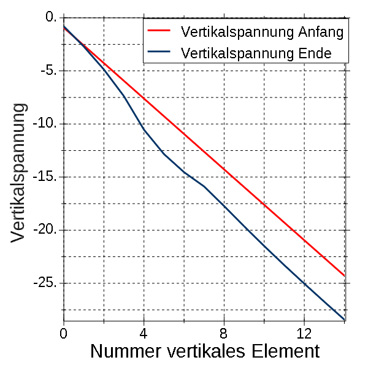

Figure 9.4: XY data for vertical stresses S33 for a selection of elements extracted at two points in time.

```python
PlotXYDaten(session=session, xyListe=[xydaten_anfang, xydaten_ende],
   xlabel='Nummer vertikales Element', ylabel='Vertikalspannung',
   legendeneintraege=[xydaten_anfang.name, xydaten_ende.name]);
```

### Example: Working with XY Data

Two examples of generating XY data from FieldOutputs at one point in time for a selection of nodes or elements can be seen in code 9.9 and 9.10. The resulting XY data can also be saved with `XYDatenSpeichern()` or plotted with `PlotXYDaten()` as shown before.

Code 9.9: Creating XY data for predefined nodes in ascending $z$-direction.

```python
instBoden = myodb.rootAssembly.instances['INSTBODEN'];
zielKnoten = BedingteAuswahl(elemente=instBoden.nodes,
   bedingung='(elem.coordinates[0] > var[0])', var=[0.2]);
sortierte_knotenlabels = KnotenAuswahlLabelliste(knoten=zielKnoten, sortierung=2, aufsteigend=True);
xydaten_knoten = XYDatenAnElementen(session=session, odbname=odbname, odbinstname='INSTBODEN',
   labelliste=sortierte_knotenlabels, zeitpunkt=0.05, var=('U', 'U3'), name='U3-Label');
```

Code 9.10: Creating XY data for predefined elements in descending $y$-direction.

```python
listenhilfe = ErstelleLabelsortierteGeomlist(geomliste=instBoden.nodes);
zielElemente = ElementAuswahl(elemente=instBoden.elements, punktliste=instBoden.nodes,
   listenhilfe=listenhilfe, bedingung='(punkt.coordinates[0] > punkt.coordinates[1])');
sortierte_elemlabels = ElementAuswahlLabelliste(elemente=zielElemente, punktliste=instBoden.nodes,
   sortierung=1, aufsteigend=False, listenhilfe=listenhilfe);
xydaten_elemente = XYDatenAnElementen(session=session, odbname=odbname, odbinstname='INSTBODEN',
   labelliste=sortierte_elemlabels, zeitpunkt=0.05, var=('SVAVG', 'SVAVG33'), name='SVAVG33-Label');
```

In some cases it might even be of use to create new FieldOutput data by combining existing ones. There is a special function called `SkalarenFieldOutputErstellen()` which needs a FieldOutput and operates on its data. As an example code 9.11 shows how to save the trace of the stress tensor as a FieldOutput variable.[^19]

Code 9.11: Create a new FieldOutput by combining existing results.

```python
SkalarenFieldOutputErstellen(name='Spur des Spannungstensors', session=session, odbname=odbname,
   referenzAusgabe='SVAVG', bedingung='data11+data22+data33');
```

# 10 Model Creation Template

In this chapter, a model similar to the one introduced in the »Abaqus Pile Jacking Tutorial« will be created. In contrast to the other tutorial, the focus here will be on starting with a template, i. e. general purpose structure for scripting, using exemplary code snippets when possible and adjusting them afterwards for a specific model. The resulting template is intended to be usable for various soil-structure interaction problems using a Coupled Eulerian Lagrangian approch in Abaqus/CAE.

This procedure might look burdensome when applied to a specific model. But the benefit of this structure will be more obvious when applied to more than one model.

Each part of the template is presented in detail in the following ten sections, which are divided like the structure of the template:

1. *Imports* – might always be chosen as suggested in code 10.1,
2. *Parameter Definitions* – should contain all modifiable parameters in one place to control the model. Usually, this will be the only part where changes are necessary in the script later on,
3. *Material and Contact Processing* – for all used materials and contacts,
4. *Parts* – Geometry, sets, meshes and section assignments for all parts,
5. *Assembly and Contact Applications* – Positioning of the whole model,
6. *Initial and Boundary Conditions* – Definition of the complete initial situation,
7. *Steps* – Change in loads/movement divided in single steps,
8. *Postprocessing* – Late adjustments of the model definition,
9. *Job* – Job creation and
10. *Keyword Adjustments* – Manual editing input file keywords.

## 10.1 Imports

Since the imports were already discussed in section 2.1 and 3.1, the beginning of the model creation template in code 10.1 should already look familiar.

Code 10.1: Imports and loading abapys for model creation.

```python
# -*- coding: utf-8 -*-
from part import *
from material import *
from section import *
from assembly import *
from step import *
from interaction import *
from load import *
from mesh import *
from optimization import *
from job import *
from sketch import *
from visualization import *
from connectorBehavior import *

abapys_dir = r'<X:\path\to\abapys>';

sys.path.insert(0, abapys_dir);
from abapys import *

InitialisiereAbapys(session=session, version=version, pfad=abapys_dir);
```

## 10.2 Parameter Definitions

The next part should contain all modifiable parameters for this model. Usually, all geometric variables, soil and material parameters, simulation parameters and version numbers can be found here. Since a model similar to the pile jacking model should be created, a soil part and a pile part are needed.

The relevant parameters/geometries for both parts are defined in code 10.2–10.4.[^20] For convenience, parameter unpacking can be used to easily change multiple values. If the hash sign in line 35 of code 10.2 would be removed (uncommented) and line 34 would be commented, all values for the variables in line 29 would be changed at once.[^21]

Code 10.2: Soil geometry definition block (first part).

```python
bodentiefe,   voidhoehe,  bodenbereich,             gittergroessen,      gitter_vertikal = [
#>0           >0          [radius] oder             [konstant] oder      >0
#                         [laenge/2, breite/2]      [gross, klein]
#[m]          [m]         [m] (aussen->innen)       [m] (aussen->innen)  [m]
#-----------|-----------|-------------------------|--------------------|-----------------|
 4.0        , 2.0       , [[2.0, 2.0], [1.0, 1.0]], [[0.4], [0.1]]     , 0.1             #
#5.0        , 3.0       , [[2.5, 2.5], [1.5, 1.5]], [[0.5], [0.1]]     , 0.1             #
];
```

All values in this code regarding the soil geometry are used later on by a function `Boden()` (see code 10.11) to create the soil body. Since this function is designed to create cuboid or cylindric soil bodies/partitions, all governing parameters can and should already be adjusted here. Each partition/entry in *bodenbereich* needs a corresponding entry in *gittergroessen* to define its mesh size (see also section 6.4 for an explanation of the parameters).

A model can have multiple soil layers. They can be defined as shown in code 10.3. Every depth entry in *schichten* must have a corresponding material entry in *schichtmaterial*. If the lowest layer is not equal to the height of the model (*bodentiefe*), the remaining material is filled with *restmaterial*.

Code 10.3: Soil geometry definition block (second part).

```python
schichten,  schichtmaterial,  restmaterial = [
#>[0]       >['']             >''
#[m]
#---------|-----------------|--------------|
 [4.0]    , ['Sand']        , 'Sand'       #
#---------|-----------------|--------------|
];
```

In code 10.4 all pile geometry parameters are defined. All materials (used) are defined in code 10.5. After using a general purpose elastic steel material, all material names used in the soil layer definitions in line 42 must be declared in *materialien_boden*.

Code 10.4: Pile geometry definition block.

```python
pfahllaenge,    pfahlbreite,   pfahlhoehe,    gitter_pfahl = [
#>0 oder        >0 oder        >0 oder        >0 oder [radius, hoehe]
#[start, ende]  [start, ende]  [start, ende]  oder [xwert, ywert, zwert]
#[m]            [m]            [m]            [m]
#-------------|--------------|--------------|--------------|
 1.0          , 1.0          , 10.0         , 1.0          #
#-------------|--------------|--------------|--------------|
];
```

The database names of all used materials have to be present `Materialdatenbank_20####.xlsx` (material database file), which will be read automatically later on. This file should be in the abapys directory or the directory specified with the `pfad` argument in `InitialisiereAbapys()`.

Code 10.5: Material definitions block.

```python
stahl_dichte = 7.87; # [kN/m^3]
#                   E-Modul   Querdehnz.
#                   E [kPa]   nu [-]
#                 |---------|------------|
stahl_elastisch = [ 210e6   , 0.3        ];

materialien_boden = [
#   Abaqus-Bez.   Datenbankname        Parameter-Bez.   Saettigung   Lagerungsd.   Stoffgesetz
#   >''           >''                  ''               [0-1]        [0-1]         >''
# |-------------|--------------------|----------------|------------|-------------|----------------|
  [ 'Sand'      , 'Standardparameter', ''             , 0.0        , 0.6         , 'Mohr-Coulomb' ],
# |-------------|--------------------|----------------|------------|-------------|----------------|
# Die Lagerungsdichte/Verdichtungsgrad kann bestimmt werden aus
#   a) Anfangsdichte rho_0:     I_r = (rho_0 - rho_min)/(rho_max - rho_min)
#   b) Anfangsporenzahl e_0:    I_e = (e_max - e_0)/(e_max - e_min)
];
```

Independent variables like the simulation parameters are also defined here (code 10.6).

Code 10.6: Definition of simulation parameters.

```python
viertel = 2;

# Reibung
kontakt_mit_reibung = False;
reibungskoeffizient = 0.22;

# Bewegung
pfahlgeschwindigkeit = -1.0;

# Simulationszeiten und -ausgabefrequenz
secondsperoutput = 0.05; # [s]
```

The step parameters concerning step duration and scaling factors for each step are defined next (explicit analysis). As shown in code 10.7 multiple parameters are defined in a list. In case parameters between different steps are not subject to change, individual parameter assignment might also be reasonable.

Code 10.7: Explicit steps parameter block.

```python
schritt_schwerkraft = [
#   timePeriod   scaleFactor   linearBulkViscosity   quadBulkViscosity
#   [s]          [-]           ? -?                  ? -?
# |------------|-------------|---------------------|-------------------|
    0.1        , 1.0         , 0.48                , 1.2               #
# |------------|-------------|---------------------|-------------------|
];

schritt_eindruecken = [
#   timePeriod   scaleFactor   linearBulkViscosity   quadBulkViscosity
#   [s]          [-]           ? -?                  ? -?
# |------------|-------------|---------------------|-------------------|
    1.0        , 1.0         , 0.48                , 1.2               #
# |------------|-------------|---------------------|-------------------|
];
```

At the end of the parameter definitions it is recommended to use a version history (see code 10.8). Changes can be documented here and with the use of a designated variable saved within the model name. It is also reasonable to define a suitable model name here, possibly with more adjustments by previously defined variables. Line 122 of code 10.8 does the actual creation of the model.

Code 10.8: Additional variable definitions.

```python
modellversion = 1;
#
# 1: Erstellung und erste Tests


modelname = 'PileJackingModel' + str(modellversion).zfill(2);
mdb.Model(name=modelname, modelType=STANDARD_EXPLICIT);
mymodel = mdb.models[modelname];
```

## 10.3 Material and Contact Processing

Code 10.9: Material processing.

```python
g = 9.81;
mymodel.Material(name='Stahl');
mymodel.materials['Stahl'].Density(table=((stahl_dichte, ), ));
mymodel.materials['Stahl'].Elastic(table=((stahl_elastisch[0], stahl_elastisch[1]), ));
mymodel.HomogeneousSolidSection(material='Stahl', name='secStahl', thickness=None);

verwendeteMaterialien = sorted(set(schichtmaterial + [restmaterial]));
benoetigtUserroutine, verwendeteBodenwerte = BodenmaterialUndSectionErstellen(modell=mymodel,
   verwendeteMaterialien=verwendeteMaterialien, verfuegbareMaterialien=materialien_boden);
```

Although surface-to-surface contact can be more efficient, using the general contact formulation for interactions in a model is easy to set up and can provide a realistic contact behaviour. The template uses normal contact by default but allowes to decide, if friction behaviour should be used as well. Code 10.10 specifies all necessary commands for normal and tangential contact behaviour (in the whole model), which is applied later in code 10.14.

Code 10.10: Contact initialisation.

```python
mymodel.ContactProperty('Kontakt');
mymodel.interactionProperties['Kontakt'].NormalBehavior(allowSeparation=ON,
   constraintEnforcementMethod=DEFAULT, pressureOverclosure=HARD);
if (kontakt_mit_reibung):
   mymodel.interactionProperties['Kontakt'].TangentialBehavior(
      dependencies=0, directionality=ISOTROPIC, elasticSlipStiffness=None,
      formulation=PENALTY, fraction=0.005, maximumElasticSlip=FRACTION,
      pressureDependency=OFF, shearStressLimit=None, slipRateDependency=OFF,
      table=((reibungskoeffizient, ), ), temperatureDependency=OFF);
else:
   mymodel.interactionProperties['Kontakt'].TangentialBehavior(formulation=FRICTIONLESS);
```

## 10.4 Parts

Next, the soil and pile part are to be created. For generating the soil body, the `Boden()` function is used in line 162–165 of code 10.11. Usually, all parameters defined in section 10.2 are just inserted in the function as shown here. Afterwards the part is referenced by the variable *partBoden* in line 166 and a section is assigned to it.

Code 10.11: Soil part.

```python
Boden(modell=mymodel, name='Boden', bodentiefe=bodentiefe, voidhoehe=voidhoehe,
   bodenbereich=bodenbereich, gittergroessen=gittergroessen, gitter_boden_vertikal=gitter_vertikal,
   schichten=schichten, schichtmaterial=schichtmaterial, restmaterial=restmaterial,
    viertel=viertel, xypartition=[False, False], partition_durchziehen=True);
partBoden = mymodel.parts['Boden'];
partBoden.SectionAssignment(offset=0.0, offsetField='', offsetType=MIDDLE_SURFACE,
   region=partBoden.sets['setAll'], sectionName='secEuler', thicknessAssignment=FROM_SECTION);
```

For the pile part a cuboid is used in this example (`Quader()` function in line 175–177). abapys provides other functions to create simple geometries, (screw) pile profiles or extruding/revolving a sketch (see section 6.2 for a list of those functions and their usage).

The pile part is also referenced by a variable (*partPfahl* in line 178) and a section is assigned.

Code 10.12: Pile part.

```python
Quader(modell=mymodel, name='Pfahl', laenge=pfahllaenge, breite=pfahlbreite,
   hoehe=pfahlhoehe, materialtyp=DEFORMABLE_BODY, gittergroesse=gitter_pfahl, rp=True,
   xypartition=[False, False], viertel=viertel);
partPfahl = mymodel.parts['Pfahl'];
partPfahl.SectionAssignment(offset=0.0, offsetField='', offsetType=MIDDLE_SURFACE,
   region=partPfahl.sets['setAll'], sectionName='secStahl', thicknessAssignment=FROM_SECTION);
```

## 10.5 Assembly and Contact Applications

Code 10.13: Assembly of the model.

```python
mymodel.rootAssembly.regenerate();
instBoden = mymodel.rootAssembly.instances['instBoden'];
instPfahl = mymodel.rootAssembly.instances['instPfahl'];
mymodel.rootAssembly.translate(vector=(0.0, 0.0, -bodentiefe), instanceList=('instBoden', ));
```

As we started working in the assembly, we apply the contact formulation defined previously as shown in code 10.14.

Code 10.14: Explicit General Contact application.

```python
mymodel.ContactExp(createStepName='Initial', name='Allgemeinkontakt');
mymodel.interactions['Allgemeinkontakt'].includedPairs.setValuesInStep(
   stepName='Initial', useAllstar=ON);
mymodel.interactions['Allgemeinkontakt'].contactPropertyAssignments.appendInStep(
   assignments=((GLOBAL, SELF, 'Kontakt'), ), stepName='Initial');
```

## 10.6 Initial and Boundary Conditions

Code 10.15: Initial soil pressure distribution.

```python
Materialschichtliste = schichtmaterial + [restmaterial];
BodenspannungErstellen(modell=mymodel, bodenname='Boden', nullspannung=0.0, voidhoehe=voidhoehe,
   schichten=schichten, bodentiefe=bodentiefe, materialschichten=Materialschichtliste,
   verwendeteBodenwerte=verwendeteBodenwerte, verwendeteMaterialien=verwendeteMaterialien);
```

Next, all materials within an Eulerian body have to be assigned to it. Code 10.16 first assigns all materials used (line 209–211) and then assignes the list to the soil instance in line 213–214.

Code 10.16: Assign Eulerian materials.

```python
assignmentList = [];
for idxMaterial, tempMaterial in enumerate(verwendeteMaterialien):
   assignmentList += ((instBoden.sets['set' + tempMaterial],
      Einheitsvektor(len(verwendeteMaterialien), idxMaterial)), );

mymodel.MaterialAssignment(assignmentList=assignmentList,
   instanceList=(instBoden, ), name='Materialzuweisung', useFields=False);
```

Any other conditions (like rigid body for the steel pile) are defined here as shown in code 10.17.

Code 10.17: Rigid body definition for pile.

```python
mymodel.RigidBody(bodyRegion=instPfahl.sets['setAll'], name='StarrerPfahl',
   refPointRegion=instPfahl.sets['setRP']);
```

Now all boundary conditions have to be created and assigned to properly defined geometry sets. If a cylindric soil body should generated, the `Boden()` function automatically creates a set *setMantelflaeche* for the curved lateral faces. Also when either a cuboid body should be generated or just half/a quarter of a cylinder, sets will be created of all outer faces (named by the normal of those faces). Therefore, the sets *setXFlaeche* and/or *setYFlaeche* might also be present. The bottom set *setUnterseite* is always created by `Boden()`. As shown in code 10.18 from line 219 onward, this template checks the existance of those sets and applies all eligible boundary conditions for the soil body. The boundary condition controlling the pile (by using the reference point or more precisely its set) is defined in line 235–237.

Code 10.18: Boundary conditions for soil body and pile.

```python
if (instBoden.sets.has_key('setMantelflaeche')):
   mymodel.VelocityBC(amplitude=UNSET, createStepName='Initial', distributionType=UNIFORM,
      fieldName='', name='bcBodenMantel', region=instBoden.sets['setMantelflaeche'],
      localCsys=None, v1=0.0, v2=0.0, v3=UNSET, vr1=UNSET, vr2=UNSET, vr3=UNSET);
if (instBoden.sets.has_key('setXFlaeche')):
   mymodel.VelocityBC(amplitude=UNSET, createStepName='Initial', distributionType=UNIFORM,
      fieldName='', name='bcBodenX', region=instBoden.sets['setXFlaeche'],
      localCsys=None, v1=0.0, v2=UNSET, v3=UNSET, vr1=UNSET, vr2=UNSET, vr3=UNSET);
   mymodel.VelocityBC(amplitude=UNSET, createStepName='Initial', distributionType=UNIFORM,
      fieldName='', name='bcBodenY', region=instBoden.sets['setYFlaeche'],
      localCsys=None, v1=UNSET, v2=0.0, v3=UNSET, vr1=UNSET, vr2=UNSET, vr3=UNSET);

mymodel.VelocityBC(amplitude=UNSET, createStepName='Initial', distributionType=UNIFORM,
   fieldName='', name='bcBodenUnten', region=instBoden.sets['setUnterseite'],
   localCsys=None, v1=UNSET, v2=UNSET, v3=0.0, vr1=UNSET, vr2=UNSET, vr3=UNSET);

mymodel.VelocityBC(amplitude=UNSET, createStepName='Initial',
   distributionType=UNIFORM, fieldName='', localCsys=None, name='bcPfahlSteuerung',
   region=instPfahl.sets['setRP'], v1=0.0, v2=0.0, v3=0.0, vr1=0.0, vr2=0.0, vr3=0.0);
```

## 10.7 Steps

Code 10.19: Definition of explicit step ”Schwerkraft“.

```python
mymodel.ExplicitDynamicsStep(name='Schwerkraft', previous='Initial',
   timePeriod=schritt_schwerkraft[0], scaleFactor=schritt_schwerkraft[1],
   linearBulkViscosity=schritt_schwerkraft[2], quadBulkViscosity=schritt_schwerkraft[3]);
```

In the first custom defined step, all output requests can be set up. Here the standard output requests are renamed and their time interval is adjusted (line 248–252 of code 10.20). Additionally two new field output requests are created in line 261–267 and a history output request afterwards. Depending on the usage of an external subroutine for materials, `SDV` is also added to the list of requested output variables in line 254–259.

Code 10.20: FieldOutput and HistoryOutput requests.

```python
mymodel.fieldOutputRequests.changeKey(fromName='F-Output-1', toName='FieldOutAll');
mymodel.historyOutputRequests.changeKey(fromName='H-Output-1', toName='HistoryOutAll');
mymodel.fieldOutputRequests['FieldOutAll'].setValues(variables=('U', ),
   timeInterval=secondsperoutput);
mymodel.historyOutputRequests['HistoryOutAll'].setValues(timeInterval=secondsperoutput);

if (benoetigtUserroutine):
   userroutineDatei = userroutine;
   variables = ('A', 'SVAVG', 'EVF', 'SDV');
else:
   userroutineDatei = '';
   variables = ('A', 'SVAVG', 'EVF');

mymodel.FieldOutputRequest(createStepName='Schwerkraft', name='FieldOutBodenIn',
   timeInterval=secondsperoutput, rebar=EXCLUDE, sectionPoints=DEFAULT, variables=variables,
   region=instBoden.sets['setAll']);

mymodel.FieldOutputRequest(createStepName='Schwerkraft', name='FieldOutPfahl',
   timeInterval=secondsperoutput, rebar=EXCLUDE, sectionPoints=DEFAULT, variables=('S', ),
   region=instPfahl.sets['setAll']);

mymodel.HistoryOutputRequest(createStepName='Schwerkraft', name='HistoryOutPfahl', rebar=EXCLUDE,
   region=instPfahl.sets['setRP'], sectionPoints=DEFAULT, timeInterval=secondsperoutput,
   variables=('RF1', 'RF2', 'RF3', 'RM1', 'RM2', 'RM3'));
```

Loads like gravity can be applied in any step after the initial conditions (see code 10.21).

Code 10.21: Assignment of gravity force.

```python
mymodel.Gravity(comp3=-g, createStepName='Schwerkraft', distributionType=UNIFORM,
   field='', name='Schwerkraft');
```

Similar to code 10.19 other steps can be defined as shown in code 10.22.

Code 10.22: Definition of explicit step ”Eindruecken“.

```python
mymodel.ExplicitDynamicsStep(name='Eindruecken', previous='Schwerkraft',
   timePeriod=schritt_eindruecken[0], scaleFactor=schritt_eindruecken[1],
   linearBulkViscosity=schritt_eindruecken[2], quadBulkViscosity=schritt_eindruecken[3]);
```

Loads and boundary conditions can be changed in steps after their definition. In this example we are interested in the soil stresses and pile reaction forces when driving a pile with constant speed into the soil body. The constant speed is defined as a (change of the) boundary condition as can be seen in code 10.23.

Code 10.23: Modifications of boundary conditions.

```python
mymodel.boundaryConditions['bcPfahlSteuerung'].setValuesInStep(stepName='Eindruecken',
   v3=pfahlgeschwindigkeit);
```

## 10.8 Postprocessing

This section becomes important when transfering states from an output database to a new model. In general everything needing a fully created model will but not yet a written out job should be handled here. An example for transfering states with `Zustandsuebertragung()` or applying initial solutions with one of the other available abapys functions can be seen in section 7.

## 10.9 Job

At this point the model is almost finished. To conduct the simulation, a job has to be created. The commands shown in code 10.24 can be adjusted (e. g. adjust *numCpus* or *numDomains* if more CPUs or domains are to be used respectively) but should already provide reasonable default values for small models.

Code 10.24: Job creation.

```python
mdb.Job(activateLoadBalancing=False, atTime=None, contactPrint=OFF,
    description='', echoPrint=OFF, explicitPrecision=DOUBLE_PLUS_PACK,
    historyPrint=OFF, memory=90, memoryUnits=PERCENTAGE, model=modelname,
    modelPrint=OFF, multiprocessingMode=DEFAULT, name=modelname,
    nodalOutputPrecision=FULL, numCpus=2, numDomains=2,
    parallelizationMethodExplicit=DOMAIN, queue=None, resultsFormat=ODB,
    scratch='', type=ANALYSIS, userSubroutine=userroutineDatei, waitHours=0, waitMinutes=0);

myjob = mdb.jobs[modelname];
```

## 10.10 Keyword Adjustments

There are some cases, when manual intervention after model and job creation is still necessary, because Abaqus/CAE doesn’t provide the desired functionality (yet). By accessing the keyword block, all input file entries can be read, modified and extended. To find a certain pattern, all keyword entries are investigated. A match with a certain phrase like in line 307 of code 10.25 allows modification of the matched block. Figure 10.1 shows the model created with the template and its default parameters presented in this chapter.

Code 10.25: Keyword changes.

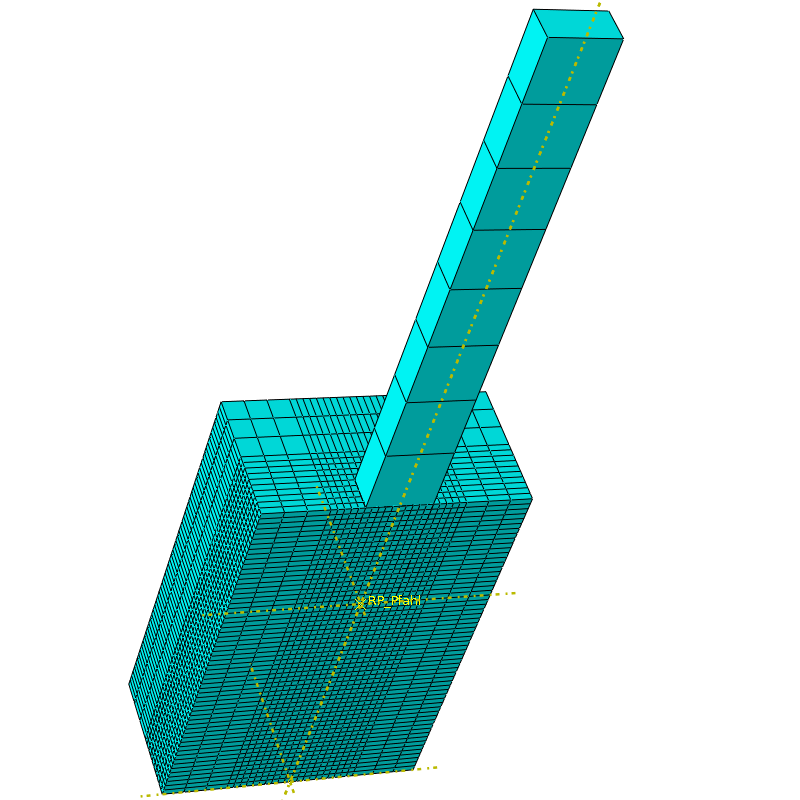

Figure 10.1: Model created with code and parameters described in this chapter.

```python
mymodel.keywordBlock.synchVersions(storeNodesAndElements=False);
for idx, text in enumerate(mymodel.keywordBlock.sieBlocks):
   if (text == '*Contact, op=NEW'):
      mymodel.keywordBlock.replace(idx, '*Contact');

myjob.writeInput(consistencyChecking=OFF);
```

# 11 Closing Remark on a Graphical User Interface to Create Scripts

This document does not cover all functionalities of abapys but it provides an overview over its most important fuctions and contains some ideas on model creation and output processing. Using and adapting the presented functions in a different context requires some knowledge about Python scripting in Abaqus (i. e. a basic understanding of Python and functions/structures in Abaqus). So it is recommended to create your own scripts, experiment with the given examples and learn when and how to use them.

An additional way to get started with the basics of generating scripts for model creation or output processing (using some abapys function) is provided by the *abapys_front* template for the SimpleScriptGenerator (found at https://github.com/d-zo/SimpleScriptGenerator).

SimpleScriptGenerator is a graphical frontend to interactively create scripts based on modifiable code templates. The *abapys_front* template allowes to create ready-to-use Python scripts for Abaqus (e. g. the model presented in section 10 can be reproduced graphically). The resulting scripts can be run in Abaqus to see their effect and investigated in a text editor to understand the code. Adjusting parameters in the graphical frontend and inspecting its effects hopefully makes it easier to understand scripting in Abaqus and to start exploring what abapys has to offer.

[^1]: Composed of ABAqus PYthon Scripting. There is another project named `abapy` which has a similar scope. This library is not related to that project in any way.
[^2]: HTML-version: https://d-zo.github.io/abapys/pilejackingexample.html (for a pdf-version change the suffix to `.pdf`).
[^3]: Currently abapys and its documentation are written in german.
[^4]: This statement has to be constrained for at least two reasons: Selection in Abaqus is depending on the amount/order of created elements and therefore the command has to be adjusted to be reliable. And since the exact same behaviour (and errors) will be reproduced when run again, some commands should also be adjusted or removed for a successful and uninterrupted execution.
[^5]: It might be necessary to adjust the path/command first (e. g. adding `.exe` and/or navigating to the right folder).
[^6]: Essentially this should be the directory containing the files `gewichtung.dll`, `gewichtung.so` and `Materialdatenbank_20####.xlsx`.
[^7]: The windowed viewport will have a border and titlebar, adding 10 px horizontally and 31 px vertically (which will be subtracted internally).
[^8]: The advantage of doing it graphically is that the viewport window will be resized in steps of pixels. Therefore the scaling factor can be obtained with a good precision in the described manner. If the size is changed directly (e. g. by `myviewport.setValues(width=..., height=...)`), the accuracy of the scaling factor will be poor, if the values do not represent an exact pixel position.
[^9]: A possible timestamp could be (assuming `myodb` and `myviewport` to be valid references): `zeitstempel = myodb.userData.Text(referencePoint=TOP_RIGHT, anchor=TOP_RIGHT, color='#000000',` `text='2020-01-05', name='date', font='-*-liberation sans l-bold-r-normal-*-*-180-*-*-p-*-*-*',` `offset=(0.0, 0.0)); myviewport.plotAnnotation(annotation=zeitstempel);`
[^10]: Execute `session.journalOptions.setValues(recoverGeometry=COORDINATE, replayGeometry=COORDINATE)` at startup to log the actual sequences instead of the masked sequences.
[^11]: Some objects like odb result data have nodeLabel or an elementLabel attributes (instead of a normal label).
[^12]: `BedingteAuswahl()` also supports a small set of mathematical expressions (if needed): `sqrt()`, `sin()`, `cos()`, `tan()`, `asin()`, `acos()` and `atan()`.
[^13]: The nodes just have to be in the list, so it is perfectly fine to pass all nodes of the instance to `punkteliste`.
[^14]: Make sure that the meaning of each variable is easy to understand, if only single characters and no descriptive names are chosen.
[^15]: It is also possible to transform the source coordinates with the optional `odbknoten`-argument, but the default way is to use `mdbknoten`.
[^16]: The introductory note in section 7 on supported/tested element types also applies here.
[^17]: See also code 5.2 and figure 2.1 for accessing instances in a model database or output database.
[^18]: When saving plots with `BildSpeichern()`, it is recommended to use `hintergrund=True`.
[^19]: While many variations are possible with this functions, the trace of a stress tensor has its own function `SpannungsSpurAlsFieldOutput()`.
[^20]: When combining all code snippets in this chapter, some lines might seem to be missing (like line 23–28 of `modelcreation.py`). Those lines are either empty or have structural comments.
[^21]: This approach can be very useful if a parameter study is to be conducted.
[^22]: The regeneration command is also necessary when a new part is the created and instantiated from the assembly of multiple simpler parts.